# INET40710 Final Project: Gaussian Mixture Model

## Overview

Many of today's major machine learning techniques require extremely large amounts of data to converge. Often times there just isn't enough, and getting more samples may be difficult or costly. Gathering hand written text in a clear and organized way can be very tedious and taxing on the poor creator (me). Modern neural networks can be used to classify hand written digits, but can require tens of thousands of samples before they converge. We can use clustering and statistics to create new similar looking data that can perform as brand new samples for these large neural networks without having to write them yourself. You can turn a few thousand samples into an unlimited source that retains the same statistical properties of the original data using a mixture of Gaussians.

#### Parametric models

Parametric models assumes that our data obeys a single type of distribution up to a set of best fit parameters. In many data sets we may have reason to believe that our samples follow a mixture of two or more sets of parameters on a distribution. If we assume that our data follows a Gaussian distribution centered around several clustered points we can use a Gaussian Mixture Model to find a maximum likelihood for k distributions.

Recall that Gaussian distribution is described by 2 parameters, mean and variance. A maximum likelihood estimation for a Gaussian distribution finds a mean and variance such that a the data set would most likely be produced by taking samples of a Gaussian distribution with those parameters. from https://en.wikipedia.org/wiki/Maximum_likelihood_estimation#Continuous_distribution,_continuous_parameter_space the log likelihood of the Gaussian distribution is:

$log(\mathcal{L}(\mu,\sigma|\mathcal{X})) = -\frac{N}{2}log(2\pi\sigma^2)-Nlog\sigma^2-\frac{\sum_{t}(x^t-\mu)^2}{2\sigma^2}$

Maximizing the MLE for each parameter yeilds:

$\hat{\mu} = \frac{\sum_{t}x^t}{N}$ and $\hat{\sigma}^2 = \frac{\sum_{t}(x^{t}-\hat{\mu})^2}{N}$

such thta $x^t$ is the $t^{th}$ sample, and $N$ the total number of samples.

#### Expectation-Maximization

GMM is an Expectation-Maximization algorithm which means that it is unsupervised beyond knowing or guessing the number of distributions that the data follows. The most familiar E-M algorithm is k-means, which attempts to cluster groups around k centroids.

```python
%matplotlib inline
import matplotlib.pyplot as plt
import seaborn as sns; sns.set()
import numpy as np
import cv2
from sklearn.mixture import GaussianMixture as GMM
```

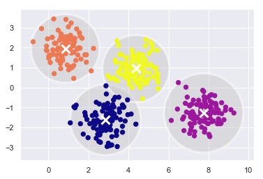

```python
# Generate some data
from sklearn.datasets.samples_generator import make_blobs
X, y_true = make_blobs(n_samples=400, centers=4,
                       cluster_std=0.60, random_state=0)
X = X[:, ::-1] # flip axes for better plotting

from sklearn.cluster import KMeans
from scipy.spatial.distance import cdist

def plot_kmeans(kmeans, X, n_clusters=4, rseed=0, ax=None):
    labels = kmeans.fit_predict(X)

    # plot the input data
    ax = ax or plt.gca()
    ax.axis('equal')
    ax.scatter(X[:, 0], X[:, 1], c=labels, s=40, cmap='plasma', zorder=2)

    # plot the representation of the KMeans model
    centers = kmeans.cluster_centers_
    radii = [cdist(X[labels == i], [center]).max()
             for i, center in enumerate(centers)]
    for c, r in zip(centers, radii):
        ax.add_patch(plt.Circle(c, r, fc='#CCCCCC', lw=3, alpha=0.5, zorder=1))
        ax.plot(c[0],c[1], 'wx', markersize = 12, mew=3)

kmeans = KMeans(n_clusters=4, random_state=0)
plot_kmeans(kmeans, X)
```

Above is a simple visualization of the k-means algorithm with k = 4. The data is assigned a cluster based around the centroid labeled with a white cross. Every point has a membership to one of the k clusters. The classes could easily be picked out by the human eye without a need for a whole algorithm. The algorithm assumes a circular distribution around a center, but we know that this is generally not true. Elongated clusters are plotted with their respective k-means areas. There are some very clear clusters, but none fit the assumed circular form.

```python
from matplotlib.patches import Ellipse

def draw_ellipse(position, covariance, ax=None, **kwargs):
    """Draw an ellipse with a given position and covariance"""
    ax = ax or plt.gca()

    # Convert covariance to principal axes
    if covariance.shape == (2, 2):
        U, s, Vt = np.linalg.svd(covariance)
        angle = np.degrees(np.arctan2(U[1, 0], U[0, 0]))
        width, height = 2 * np.sqrt(s)
    else:
        angle = 0
        width, height = 2 * np.sqrt(covariance)

    # Draw the Ellipse
    for nsig in range(1, 4):
        ax.add_patch(Ellipse(position, nsig * width, nsig * height,
                             angle, **kwargs))

def plot_gmm(gmm, X, label=True, ax=None, points = True):
    ax = ax or plt.gca()
    if points:
        labels = gmm.fit(X).predict(X)
        if label:
            ax.scatter(X[:, 0], X[:, 1], c=labels, s=40, cmap='plasma', zorder=2)
        else:
            ax.scatter(X[:, 0], X[:, 1], s=40, zorder=2)
        ax.axis('equal')

    w_factor = 0.2 / gmm.weights_.max()
    for pos, covar, w in zip(gmm.means_, gmm.covariances_, gmm.weights_):
        draw_ellipse(pos, covar, alpha=w * w_factor)
        ax.plot(pos[0],pos[1], 'wx', markersize = 12, mew=3)
```

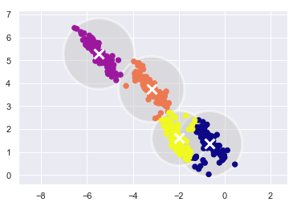

```python
rng = np.random.RandomState(13)
X_stretched = np.dot(X, rng.randn(2, 2))

kmeans = KMeans(n_clusters=4, random_state=0)
plot_kmeans(kmeans, X_stretched)
```

GMM fits k Gaussian distributions around the data to make soft clustering assignments. The center remains, but we adjust the radius based on the covariance of the cluster rather than assume a static radius.

### GMM Algorithm

From https://brilliant.org/wiki/gaussian-mixture-model/:

#### Initialization Step:

<ul type = "square">

Randomly assign samples without replacement from the dataset $X=\{x_1,...,x_N\}$ to the component mean estimates $\hat{\mu_1},...,\hat{\mu_k}$. E.g. for $K=3$ and $N=100$, set $\hat{\mu_1}=x_{45},\hat{\mu_2}=x_{32},\hat{\mu_3}=x_{10}$

Set all component variance estimates to the sample variance $\hat{\sigma_1^2},...,\hat{\sigma_K^2}=\frac{\sum_{t}(x^{t}-\hat{\mu})^2}{N}$

Set all component distributions prior estimates to the uniform distribution $\hat{\phi_1},...,\hat{\phi_K}=\frac{1}{K}$

</ul>

#### Expectation (E) Step:

Calculate $\forall i,k$:

$\hat{\gamma_{ik}}=\frac{\hat{\phi{k}}\mathcal{N}(x_i|\hat{\mu_k},\hat{\sigma_k})}{\sum_{j=1}^{K}\hat{\phi_j}\mathcal{N}(x_i|\hat{\mu_j},\hat{\sigma_j})}$

where $\hat{\gamma_{ik}}$ is the probability that $x_i$ is generated by component $C_k$. Thus, $\hat{\gamma_{ik}}=p(C_k|x_i,\hat{\phi},\hat{\mu},\hat{\sigma})$.

#### Maximization (M) Step:

Using the $\hat{\gamma_k}$ calculated in the expectation step, calculate the following in order $\forall k$:

<ul type = "square">

$\hat{\phi_k}=\sum_{i=1}^{N}\frac{\hat{\gamma_{ik}}}{N}$

$\hat{\mu_k}=\frac{\sum_{i=1}^{N}\hat{\gamma_{ik}}x_i}{\sum_{i=1}^{N}\hat{\gamma_{ik}}}$

$\hat{\sigma_k}=\frac{\sum_{i=1}^{N}\hat{\gamma_{ik}}(x_i-\hat{\mu_k})^2}{\sum_{i=1}^{N}\hat{\gamma_{ik}}}$

</ul>

In plain English, the algorithm can be summed up as:

<ul type = "square">

Pick k random data points to be means and use those to calculate k variance values. Make all priors equal.

For each data point and each centroid, calculate the probability that it belongs in each cluster.

For every cluster, calculate the soft priors, means, and variances based on the probabilities of the cluster assignments from the previous step.

Repeat until cluster soft assignment change is lower than some threshold.

</ul>

The total cost of each iteration is $\mathcal{O}(Nk)$, though under the constraint that $k \le N$ a generous estimate would be $\mathcal{O}(N^2)$.

The GMM clusters fit the elliptical data much better.

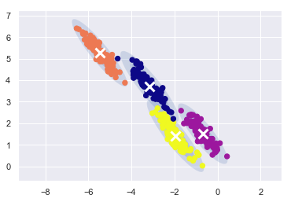

```python
gmm = GMM(n_components=4, covariance_type='full', random_state=42)
plot_gmm(gmm, X_stretched)
```

Looking closely you can see a basic relief map of $p(x|\mathcal{N}(\hat{\mu_k}, \hat{\sigma^{2}_{k}}))$

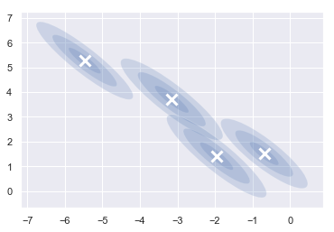

```python
plot_gmm(gmm, X_stretched, points = False)
```

Groups of pixels with high values represent the distinct features drawn. Values produced from the k cluster densities will most likely be filled with similar shape and value recreating the subtle features of handwritten glyphs. We can use GMM to detect features in image data to generate new statistically similar data.

The analysis idea and much of the code is used or modified from here:

https://jakevdp.github.io/PythonDataScienceHandbook/05.12-gaussian-mixtures.html

## Data

The data was hand written by myself on paper. I printed a grid on a page and filled out around 1500 hand written digit samples. The page was the photocopied and uploaded as an image.

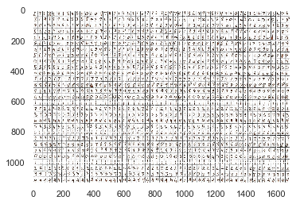

```python
test = cv2.imread('numbersCorrected2.png', cv2.COLOR_RGB2GRAY)
plt.imshow(test)
plt.show()
```

Much of the color is stripped from the image. Every pixel under a threshold is turned to a minimum white value. This accentuates the numbers while clearing much of the noise.

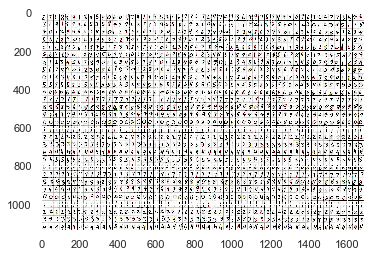

```python
thresh = 127
test= cv2.threshold(test, thresh, 255, cv2.THRESH_TOZERO)[1]
plt.imshow(test)
plt.show()
```

Reading each digit as its own data point took some trial and error as the digit sheet was difficult to perfectly align in the scanner. The picture was sliced into rectangles around each digit with some buffer space to avoid capturing the grid borders. Since the scan wasn't perfect, small adjustments were needed to realign the slicing procedure as the scanned grid axis tended to drift.

```python
y_begin = 8
y_len = 34
y_buffer = 4
x_begin = 37
x_len = 26
x_buffer = 4
x_tot = len(test[1])
y_tot = len(test[0])
numbers = []
x_count = 1
y_count = 1
while y_begin < y_tot:
    while x_begin < x_tot:
        numbers.append(test[y_begin+3:(y_begin +y_len), x_begin+3:(x_begin+ x_len - 1)])
        #plt.imshow(numbers[-1])
        #plt.show()
        if x_count % 5 == 0:
            x_begin +=3
        x_begin +=  x_len + x_buffer
        x_count+=1
    x_begin = 37
    if y_count % 4 == 0:
        y_begin += 4
    x_count = 1
    y_count += 1
    y_begin += y_len + y_buffer
```

## Exploratory Data Analysis

A close look at the data will show the pixel values. A computer can read this fine, but a human will need to understand the data represented visually. Each number is a 31 by 22 pixel rectangle with 3 RGB values.

```python
print(numbers[3].shape)
```

```
(31, 22, 3)
```

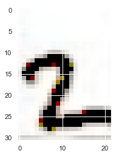

```python
plt.imshow(numbers[3])
plt.show()
```

The color of each pixel is not important, so we can reduce the size of the data by replacing the RGB tuple to the max value of each color to represent the brightness of each pixel. The data can be further simplified by resizing each number to a 10 x 10 pixel grid.

```python
def rgb2single(number):
    num = []
    for row in number:
        for pix in row:
            #num.append(np.average(pix))
            num.append(np.max(pix))
    num = np.asarray(num)
    num = 255 - num
    return num
```

```python
new_shape = (10,10)
digs = []
for number in range(len(numbers)):
    if 0 not in numbers[number].shape:
        numbers[number] = cv2.resize(numbers[number], new_shape, interpolation = cv2.INTER_AREA)
    n = rgb2single(numbers[number])
    digs.append(n)

digs = np.asarray(digs)
digs = np.asarray([y for y in digs if 0 not in y.shape])
```

The scan is clear, but the GMM algorithm will consider noise artifacts from the edges of the lines or shade of the paper used as an important feature. We can denoise this by setting a threshold for pixel values and setting anything lower than it to 0. This makes the background consistently 0 and keeps the variance concentrated on where the digits have been written rather than edges and corners where there is mostly white space. You might be able to "see" the 2 written in the pixel data.

```python
thresh = 10
for i in range(len(digs)):
    digs[i][digs[i] < thresh] = 0
formatting = "%3d " * new_shape[1]
for i in range(new_shape[0]):
    p = ()
    for j in range(new_shape[1]):
        p += (digs[3][i*new_shape[0] + j],)
    print(formatting % p)
```

```
  0   0   0   0   0   0   0   0   0   0
  0   0   0   0   0   0   0   0   0   0
  0   0   0   0   0   0   0   0   0   0
  0  19  57 124 135  42   0   0   0   0
 61 202 175 129 197 188  10   0   0   0
 57 121  16   0 146 153   0   0   0   0
  0   0   0  87 232  49   0   0   0   0
  0   0  42 197  82  13  21  73  87  81
  0   0 123 255 194 241 234 195 194 199
 20  19  36  82  40  36  35  23  20  26
```

```python
def plot_digits(data):
    fig, ax = plt.subplots(10, 10, figsize=(32, 22),
                           subplot_kw=dict(xticks=[], yticks=[]))
    fig.subplots_adjust(hspace=0.05, wspace=0.05)
    for i, axi in enumerate(ax.flat):
        im = axi.imshow(data[i].reshape(new_shape[0], new_shape[1]), cmap='binary')
        im.set_clim(0, 255)
```

The result is very simplified, but still a clear representations of the handwritten digits.

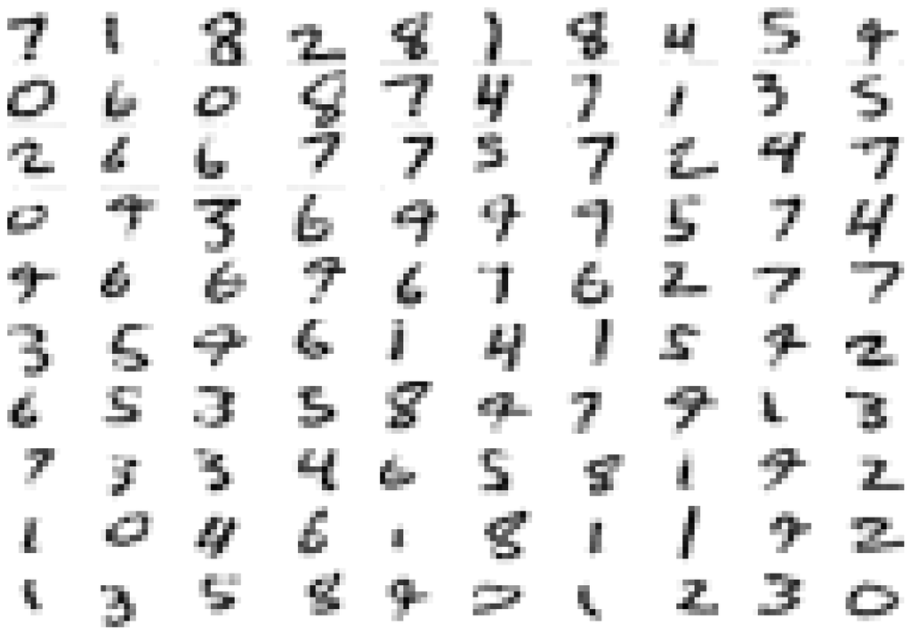

```python
plot_digits(digs)
```

Any E-M algorithm must recalculate after considering each data point, so it is optimal to reduce the number of features as much as possible. We reduced the variance of consistent white space meanining that we can use PCA to eliminate those pixels when generating the GMM model. Most likely corner and edge pixels will never be drawn on. They do not need to be considered in our model and can be reconstructed to bring the reduced feature set back to the original 10 x 10 picture size.

```python
from sklearn.mixture import GaussianMixture as GMM
from sklearn.decomposition import PCA
pca = PCA(0.99, whiten=True)
data = pca.fit_transform(digs)
data.shape
```

```
(1566, 74)
```

A conservative 99% PCA capture rate still eliminates more than 25% of our pixels. This means that only 3/4 of each picture contains 99% of pixel data.

## Models

E-M algorithms need some k value to determine how many clusters to use. The examples before used $k=4$ as the clusters were obvious to the human eye. Our k value will represent the small features of my handwriting that make it unique. This might include a small fluctuations of the curves of an 8 or maybe the short line segment at the back of the 4. It would be difficult to determine all of these feature clusters by visual inspection, so instead we can use an AIC value to determine a reasonable k. If the k is too high, the model will be overfit. This would produce clearer results, but may be too close to the original input data. If the k value is too low then the results may be too general and probably would look more like random data.

From https://en.wikipedia.org/wiki/Akaike_information_criterion#Definition, AIC is defined as:

$AIC = 2k -2ln(\hat{\mathcal{L}})$

In brief, we pick a minimum AIC value such that the maximum likelihood is balanced with the number of cluster centers that produced it. A general trend can be found by plotting values in steps of 10.

```
Wall time: 15.4 s
```

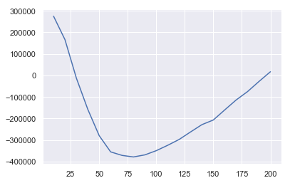

```python
%%time
n_components = np.arange(10, 210, 10)
models = [GMM(n, covariance_type='full', random_state=0)
          for n in n_components]
aics = [model.fit(data).aic(data) for model in models]
plt.plot(n_components, aics);
```

Let's take a closer look at the minimum value range. We can find an optimal value around 72.

```
Wall time: 29.2 s
```

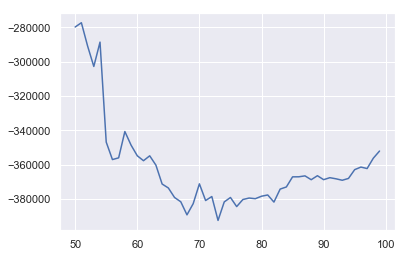

```python
%%time
n_components = np.arange(50, 100, 1)
models = [GMM(n, covariance_type='full', random_state=0)
          for n in n_components]
aics = [model.fit(data).aic(data) for model in models]
plt.plot(n_components, aics);
```

The k value found by the minimum AIC value is used to construct a GMM model from the data. The algorithm is run until convergence. This means that the parameters cease to update from previous iterations. The model is unsupervised which means that we can get right into it without any training or testing. We can use the whole data set.

```python
%%time
print("Minimum AICS suggests number of components should be: %d" % 72)
gmm = GMM(72, covariance_type='full', random_state=0)
gmm.fit(data)
print(gmm.converged_)
```

```
Minimum AICS suggests number of components should be: 72
True
Wall time: 516 ms
```

100 samples are pulled from the resulting distribution and reconstructed by reversing the PCA transformation back into the 10 x 10 matrix. That data is plotted to examine the results. Keep in mind that these results are artificially produced numbers. The goal was to create new samples with similar visual traits as the original, though the results have no objective labels so traditional objective measure may not be applicable. Certainly not all the results are clear, so a measurable goodness may be the percent of samples that are distinguishable as numbers. I would estimate that around 50% of the samples can be distinguished as some number.

```python
data_new = gmm.sample(100)
```

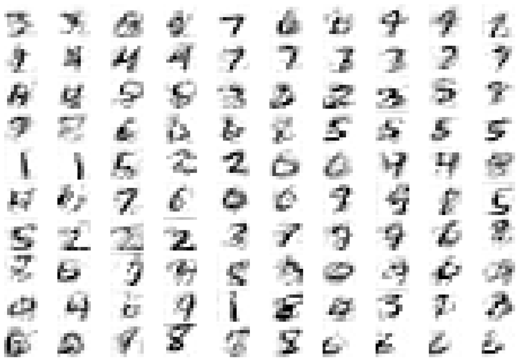

```python
digits_new = pca.inverse_transform(data_new[0])
digits_new.shape
plot_digits(digits_new)
```

## Conclusion

The results have some very plausible numbers but resizing and feature reduction has reduced the visibility. This model could be used to pad data sets used for digit classification. Pulls from the distribution could be classfied with human help as either a digit or tossed if unclear. This data can be used to help digit recognition neural networks get the larger data set needed without having to use manual human labor to write it all.

I learned that even simple models such as GMM can produce surprising results. Image data is difficult to classify for computers, but second nature to humans. It may be possible to analyze the clusters to see what important features stand out in each picture so that it can be used to help other models classify images.

I think visually clearer data could be produced by loosening the dimensionality restrictions. Experimenting with dimension size vs noise may be a good avenue to further study this GMM example. I'd also like to expand this analysis with not only digits, but a full handwritten alphabet. Currently I've been working an alphabetic dataset but ran out of time to complete it.